# Bellabeat Capstone Project Using R Programming Language

Eliana Walters

2024-03-22

This is a project documentation for Bellabeat case study from the Google Data Analytics Course. This analysis follows the six(6) steps of Data analysis: Ask, Prepare, Process, Analyse, Share, and Act, as taught in the Google Data Analytics Courses.

[figure not shown]

Female App Tracker User

I am a junior analyst working on the marketing analysis team at Bellabeat, a high-tech manufacturer of health-focused products for women. As a data analyst, I have been asked to focus on one of Bellabeat’s products: Bellabeat app and analyze smart device fitness data to gain insights into how customers use their smart devices.The insights gained from my analysis will help guide Bellabeat’s marketing strategy. I will present my findings and recommendations to Bellabeat executive team.

**About the company**

Urška Sršen and Sando Mur founded Bellabeat, a high-tech company that manufactures health-focused smart products. Sršen used her background as an artist to develop beautifully designed technology that informs and inspires women around the world. Collecting data on activity, sleep, stress, and reproductive health has allowed Bellabeat to empower women with knowledge about their own health and habits. Since it was founded in 2013, Bellabeat has grown rapidly and quickly positioned itself as a tech-driven wellness company for women. By 2016, Bellabeat had opened offices around the world and launched multiple products. Bellabeat products became available through a growing number of online retailers in addition to their own e-commerce channel on their website. The company has invested in traditional advertising media, such as radio, out-of-home billboards, print, and television, but focuses on digital marketing extensively. Bellabeat invests year-round in Google Search, maintaining active Facebook and Instagram pages, and consistently engages consumers on Twitter. Additionally, Bellabeat runs video ads on Youtube and display ads on the Google Display Network to support campaigns around key marketing dates. Sršen knows that an analysis of Bellabeat’s available consumer data would reveal more opportunities for growth. She has asked the marketing analytics team to focus on a Bellabeat product and analyze smart device usage data in order to gain insight into how people are already using their smart devices. Then, using this information, she would like high-level recommendations for how these trends can inform Bellabeat marketing strategy.

## Characters and Products

- **Characters**

○ Urška Sršen: Bellabeat’s cofounder and Chief Creative Officer

○ Sando Mur: Mathematician and Bellabeat’s cofounder; key member of the Bellabeat executive team

○ Bellabeat marketing analytics team: A team of data analysts responsible for collecting, analyzing, and reporting data that helps guide Bellabeat’s marketing strategy. I joined this team six months ago and have been busy learning about Bellabeat’’s mission and business goals — as well as how you, as a junior data analyst, can help Bellabeat achieve them.

- **Products**

○ Bellabeat app: The Bellabeat app provides users with health data related to their activity, sleep, stress, menstrual cycle, and mindfulness habits. This data can help users better understand their current habits and make healthy decisions. The Bellabeat app connects to their line of smart wellness products.

○ Leaf: Bellabeat’s classic wellness tracker can be worn as a bracelet, necklace, or clip. The Leaf tracker connects to the Bellabeat app to track activity, sleep, and stress.

○ Time: This wellness watch combines the timeless look of a classic timepiece with smart technology to track user activity, sleep, and stress. The Time watch connects to the Bellabeat app to provide you with insights into your daily wellness.

○ Spring: This is a water bottle that tracks daily water intake using smart technology to ensure that you are appropriately hydrated throughout the day. The Spring bottle connects to the Bellabeat app to track your hydration levels.

# **ASK Phase**

2.1 Business Task Identify trends in how consumers use non-Bellabeat smart devices to apply insights into Bellabeat’s marketing strategy.

1. What are some trends in smart device usage?
2. How could these trends apply to Bellabeat customers?
3. How could these trends help influence Bellabeat marketing strategy?

**Stakeholders**

- Urška Sršen — Bellabeat’s cofounder and Chief Creative Officer
- Sando Mur — Bellabeat’s cofounder; key member of the Bellabeat executive team
- Bellabeat marketing analytics team

# **Prepare phase**

**Dataset used:** The data source used for our case study is FitBit Fitness Tracker Data. This dataset is stored in Kaggle and was made available through Mobius.

**Accessibility and privacy of data:**

Verifying the metadata of our dataset we can confirm it is open-source. The owner has dedicated the work to the public domain by waiving all of his or her rights to the work worldwide under copyright law, including all related and neighboring rights, to the extent allowed by law. You can copy, modify, distribute and perform the work, even for commercial purposes, all without asking permission.

**Information about the dataset:** These datasets were generated by respondents to a distributed survey via Amazon Mechanical Turk between 03.12.2016–05.12.2016. Thirty eligible Fitbit users consented to the submission of personal tracker data, including minute-level output for physical activity, heart rate, and sleep monitoring. Variation between output represents use of different types of Fitbit trackers and individual tracking behaviors / preferences.

**Data Organization:** There are 18 CSV documents made available for the analysis. Each document represents different quantitative data tracked by Fitbit. The data is considered long since each row is one time point per subject, so each subject will have data in multiple rows.Every user has a unique ID and different rows since data is tracked by day and time.

**Data Integrity and Credibility:** Due to the limitation of size (30 users) and not having any demographic information we could encounter a sampling bias. We are not sure if the sample is representative of the population as a whole. Another problem we would encounter is that the dataset is not current and also the time limitation of the survey (2 months long). That is why we will give our case study an operational approach.

# **process phase**

I used R for my analysis because this dataset is a big data and R is accessible, R gives me the opportunity to create data visualization to share my findings and recommendations with stakeholders.

**Setting up my R environments**

- tidyverse
- here
- lubridate
- janitor
- skimr

```r
# setting up my R environment

library(tidyverse)
library(here)
library(lubridate)
library(janitor)
library(skimr)
```

**Importing dataset**

```r
daily_activity <- read.csv("daily_activity.csv")
daily_sleep <- read.csv("daily_sleep.csv")
hourly_calories <- read.csv("hourly_calories.csv")
hourly_intensities <- read.csv("hourly_intensities.csv")
hourly_steps <- read.csv("hourly_steps.csv")
weight_log <- read.csv("weight_log.csv")
```

**Data preview**

print(“Daily Activity”) head(daily_activity)

print(“Day Sleep”) head(daily_sleep)

print(“Hourly Calories”) head(hourly_calories)

print(“Hourly Intensities”) head(hourly_intensities)

print(“Hourly Steps”) head(hourly_Steps)

print(“Weight Log”) head(weight_log)

```r
print("Daily Activity")
```

```
## [1] "Daily Activity"
```

```r
head(daily_activity)
```

```
##           Id ActivityDate TotalSteps TotalDistance TrackerDistance
## 1 1503960366    4/12/2016      13162          8.50            8.50
## 2 1503960366    4/13/2016      10735          6.97            6.97
## 3 1503960366    4/14/2016      10460          6.74            6.74
## 4 1503960366    4/15/2016       9762          6.28            6.28
## 5 1503960366    4/16/2016      12669          8.16            8.16
## 6 1503960366    4/17/2016       9705          6.48            6.48
##   LoggedActivitiesDistance VeryActiveDistance ModeratelyActiveDistance
## 1                        0               1.88                     0.55
## 2                        0               1.57                     0.69
## 3                        0               2.44                     0.40
## 4                        0               2.14                     1.26
## 5                        0               2.71                     0.41
## 6                        0               3.19                     0.78
##   LightActiveDistance SedentaryActiveDistance VeryActiveMinutes
## 1                6.06                       0                25
## 2                4.71                       0                21
## 3                3.91                       0                30
## 4                2.83                       0                29
## 5                5.04                       0                36
## 6                2.51                       0                38
##   FairlyActiveMinutes LightlyActiveMinutes SedentaryMinutes Calories
## 1                  13                  328              728     1985
## 2                  19                  217              776     1797
## 3                  11                  181             1218     1776
## 4                  34                  209              726     1745
## 5                  10                  221              773     1863
## 6                  20                  164              539     1728
```

**Check the data structure using str()**

str(daily_activity)

str(daily_sleep)

str(hourly_calories)

str(hourly_intensities)

str(hourly_steps)

str(weight_log)

```r
str(daily_sleep)
```

```
## 'data.frame':    413 obs. of  5 variables:
##  $ Id                : num  1.5e+09 1.5e+09 1.5e+09 1.5e+09 1.5e+09 ...
##  $ SleepDay          : chr  "4/12/2016 12:00:00 AM" "4/13/2016 12:00:00 AM" "4/15/2016 12:00:00 AM" "4/16/2016 12:00:00 AM" ...
##  $ TotalSleepRecords : int  1 2 1 2 1 1 1 1 1 1 ...
##  $ TotalMinutesAsleep: int  327 384 412 340 700 304 360 325 361 430 ...
##  $ TotalTimeInBed    : int  346 407 442 367 712 320 377 364 384 449 ...
```

**Format and clean dataframes** I’ve familiarized myself with the data set.I’ll check for numbers of inconsistencies and errors,and check the numbers of unique users per dataframe before cleaning.

unique(daily_activity$Id)

unique(daily_sleep$Id)

unique(hourly_calories$Id)

unique(hourly_intensities$Id)

unique(hourly_steps$Id)

unique(weight_log$Id)

```r
# unique users
unique(daily_activity$Id)
```

```
##  [1] 1503960366 1624580081 1644430081 1844505072 1927972279 2022484408
##  [7] 2026352035 2320127002 2347167796 2873212765 3372868164 3977333714
## [13] 4020332650 4057192912 4319703577 4388161847 4445114986 4558609924
## [19] 4702921684 5553957443 5577150313 6117666160 6290855005 6775888955
## [25] 6962181067 7007744171 7086361926 8053475328 8253242879 8378563200
## [31] 8583815059 8792009665 8877689391
```

All data sets have 33 participants each except the daily_sleep and weight data set which has 24 and 8 participants respectively. The weight log dataset has 8 participants which is not a sufficient amount to use for the analysis.

**Check for duplicates** sum(duplicated(daily_activity))

sum(duplicated(daily_sleep))

sum(duplicated(hourly_calories))

sum(duplicated(hourly_intensities))

sum(duplicated(hourly_steps))

```r
# checking for duplicates

sum(duplicated(daily_sleep))
```

```
## [1] 3
```

**Remove duplicates and missing values**

daily_activity <- daily_activity %>% distinct() %>% drop_na()

daily_sleep <- daily_sleep %>% distinct() %>% drop_na()

hourly_calories <- hourly_calories %>% distinct() %>% drop_na()

hourly_intensities <- hourly_intensities %>% distinct() %>% drop_na()

hourly_steps <- hourly_steps %>% distinct() %>% drop_na()

**Clean and rename columns**

clean_names(daily_activity) daily_activity <- rename_with(daily_activity, tolower)

clean_names(daily_sleep) daily_sleep <- rename_with(daily_sleep, tolower)

clean_names(daily_steps) daily_steps <- rename_with(daily_steps, tolower)

clean_names(hourly_calories) hourly_calories <- rename_with(hourly_calories, tolower)

clean_names(hourly_intensities) hourly_intensities <- rename_with(hourly_intensities, tolower)

clean_names(hourly_steps) hourly_steps <- rename_with(hourly_steps, tolower)

**Date and Time column**

daily_activity <- daily_activity %>% rename(date = activitydate) %>% mutate(date = as_date(date, format = “%m/%d/%Y”))

daily_sleep <- daily_sleep %>% rename(date = sleepday) %>% mutate(date = as.Date(date))

hourly_calories <- hourly_calories %>% rename(date_time = activityhour) %>% mutate(date_time = as.POSIXct(date_time, format =“%m/%d/%Y %I:%M:%S %p” , tz=Sys.timezone()))

hourly_intensities <- hourly_intensities %>% rename(date_time = activityhour) %>% mutate(date_time = as.POSIXct(date_time, format =“%m/%d/%Y %I:%M:%S %p” , tz=Sys.timezone()))

hourly_steps<- hourly_steps %>% rename(date_time = activityhour) %>% mutate(date_time = as.POSIXct(date_time, format =“%m/%d/%Y %I:%M:%S %p” , tz=Sys.timezone()))

```r
daily_activity <- daily_activity %>%
  rename(date = activitydate) %>%
  mutate(date = as_date(date, format = "%m/%d/%Y"))

  daily_sleep <- daily_sleep %>%
  rename(date = sleepday) %>%
  mutate(date = as.Date(date))

hourly_calories <- hourly_calories %>%
  rename(date_time = activityhour) %>%
  mutate(date_time = as.POSIXct(date_time, format ="%m/%d/%Y %I:%M:%S %p" , tz=Sys.timezone()))

hourly_intensities <- hourly_intensities %>%
  rename(date_time = activityhour) %>%
  mutate(date_time = as.POSIXct(date_time, format ="%m/%d/%Y %I:%M:%S %p" , tz=Sys.timezone()))

  hourly_steps<- hourly_steps %>%
  rename(date_time = activityhour) %>%
  mutate(date_time = as.POSIXct(date_time, format ="%m/%d/%Y %I:%M:%S %p" , tz=Sys.timezone()))
```

**4.6.4 Merging the data sets**

```r
# daily_activity_sleep <- merge(daily_activity, daily_sleep, by = "id")
```

```r
daily_activity_sleep <- merge(daily_activity, daily_sleep, by = "id")
```

# **Analyze and Share phases**

Analyzing trends of the users of FitBit to determine how my insights can drive business in BellaBeat’s marketing strategy.

**Summarize and explore each data set**

```r
daily_activity %>%
  select(totalsteps,
         totaldistance,
         sedentaryminutes, calories) %>%
  summary()
```

```
##    totalsteps    totaldistance    sedentaryminutes    calories
##  Min.   :    0   Min.   : 0.000   Min.   :   0.0   Min.   :   0
##  1st Qu.: 3790   1st Qu.: 2.620   1st Qu.: 729.8   1st Qu.:1828
##  Median : 7406   Median : 5.245   Median :1057.5   Median :2134
##  Mean   : 7638   Mean   : 5.490   Mean   : 991.2   Mean   :2304
##  3rd Qu.:10727   3rd Qu.: 7.713   3rd Qu.:1229.5   3rd Qu.:2793
##  Max.   :36019   Max.   :28.030   Max.   :1440.0   Max.   :4900
```

**Discoveries from the summary** - The Average total steps is 7638 in a day. The daily recommended amount of steps to be taken per day is 7500

**Actual Steps taken and Calories burned** I am making a visualization to see if there’s a correlation between steps taken and the amount of calories burned.

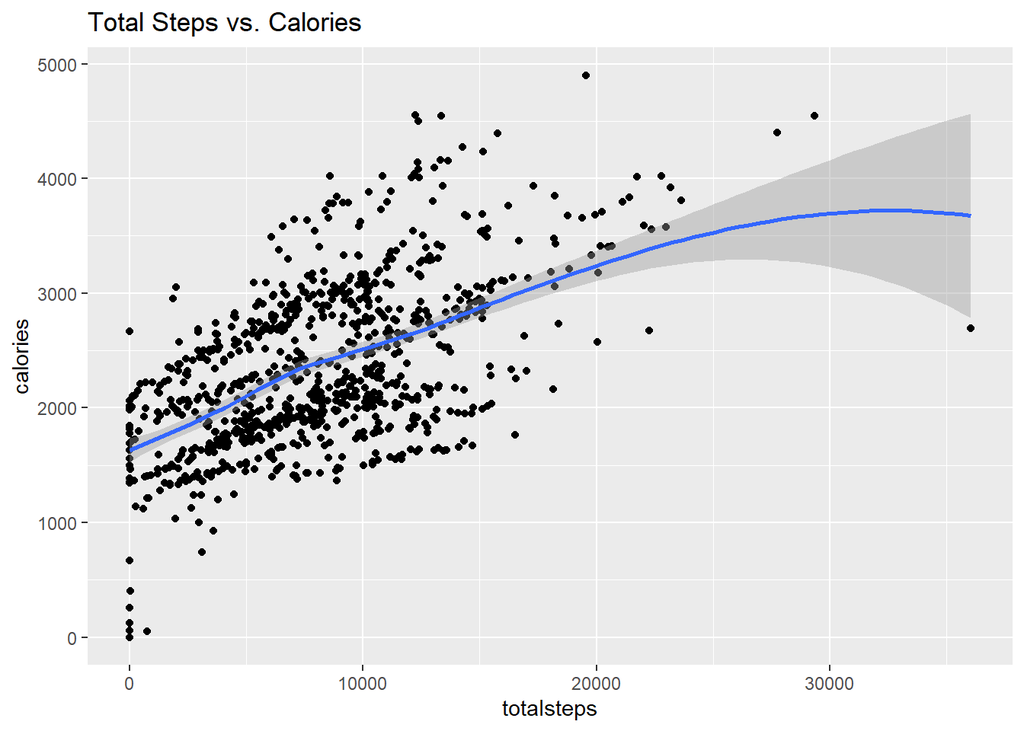

```r
ggplot(data = daily_activity, aes(x = totalsteps, y = calories)) +
  geom_point() + geom_smooth() + labs(title ="Total Steps vs. Calories")
```

There is a correlation between total steps taken and the amount of calories burned.

**Steps per weekday**

```r
 weekday_steps <- daily_activity %>%
  mutate(weekday = weekdays(date))

weekday_steps$weekday <- ordered(weekday_steps$weekday, levels = c("Monday", "Tuesday", "Wednesday", "Thursday",
                                                                   "Friday", "Saturday", "Sunday"))

weekday_steps <- weekday_steps %>%
  group_by(weekday) %>%
  summarize(daily_steps = mean(totalsteps))

head(weekday_steps)
```

```
## # A tibble: 6 × 2
##   weekday   daily_steps
##   <ord>           <dbl>
## 1 Monday          7781.
## 2 Tuesday         8125.
## 3 Wednesday       7559.
## 4 Thursday        7406.
## 5 Friday          7448.
## 6 Saturday        8153.
```

Visualize steps per weekday

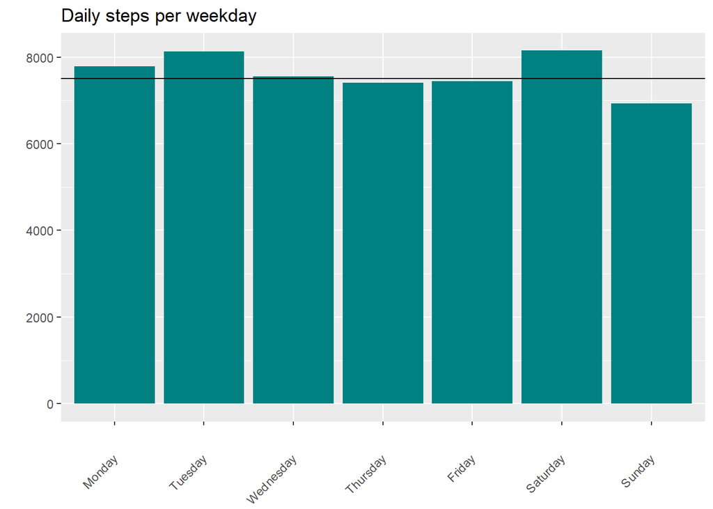

```r
ggplot(weekday_steps, aes(weekday, daily_steps)) +
  geom_col(fill ="#008080" ) +
  geom_hline(yintercept = 7500) +
  labs(title = "Daily steps per weekday", x= "", y = "") +
  theme(axis.text.x = element_text(angle = 45,vjust = 0.5, hjust = 1))
```

**Sleep per weekday** To know what day of the week users sleep the most

```r
weekday_sleep <- daily_sleep %>%
  mutate(weekday = weekdays(date))
weekday_sleep$weekday <-ordered(weekday_sleep$weekday, levels=c("Monday", "Tuesday", "Wednesday", "Thursday",
                                                                "Friday", "Saturday", "Sunday"))

weekday_sleep <-weekday_sleep %>%
  group_by(weekday) %>%
  summarize (daily_sleep = mean(totalminutesasleep))

head(weekday_sleep)
```

```
## # A tibble: 6 × 2
##   weekday   daily_sleep
##   <ord>           <dbl>
## 1 Monday           427.
## 2 Tuesday          427.
## 3 Wednesday        422.
## 4 Thursday         417.
## 5 Friday           370
## 6 Saturday         443.
```

**Make visualization**

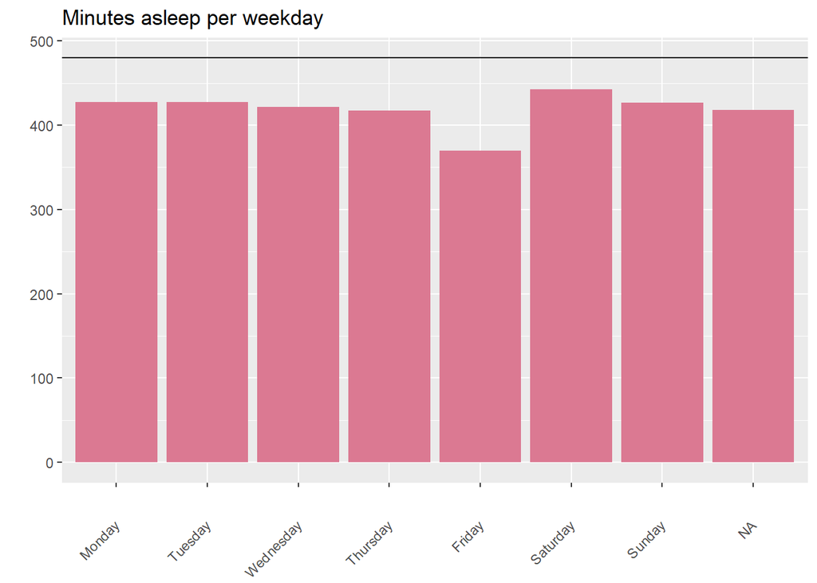

```r
ggplot(weekday_sleep, aes(weekday, daily_sleep)) +
  geom_col(fill = "#db7992") +
  geom_hline(yintercept = 480) +
  labs(title = "Minutes asleep per weekday", x= "", y = "") +
  theme(axis.text.x = element_text(angle = 45,vjust = 0.5, hjust = 1))
```

**Hourly intensities through the day**

Split the datetime column into date and time columns

```r
hourly_intensities <- hourly_intensities %>%
  separate(date_time, into = c("date", "time"), sep= " ")
head(hourly_intensities)
```

```
##           id       date     time totalintensity averageintensity
## 1 1503960366 2016-04-12     <NA>             20         0.333333
## 2 1503960366 2016-04-12 01:00:00              8         0.133333
## 3 1503960366 2016-04-12 02:00:00              7         0.116667
## 4 1503960366 2016-04-12 03:00:00              0         0.000000
## 5 1503960366 2016-04-12 04:00:00              0         0.000000
## 6 1503960366 2016-04-12 05:00:00              0         0.000000
```

```r
hourly_intensities <- hourly_intensities %>%
  group_by(time) %>%
  drop_na() %>%
  summarise(mean_total_int = mean(totalintensity))
```

Make visualization of the hourly intensities data

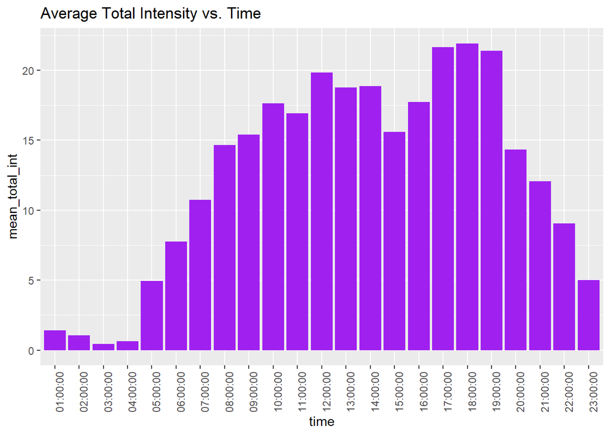

```r
ggplot(data = hourly_intensities, aes(x = time, y = mean_total_int)) + geom_histogram(stat = "identity", fill='purple') +
  theme(axis.text.x = element_text(angle = 90)) +
  labs(title="Average Total Intensity vs. Time")
```

Discoveries after analyzing hourly intensities

- People are more active between 5am and 10pm.
- Most of the activity happens between 5 pm and 7 pm — I suppose that when people are done with work for the day, they go to the gym or take a walk. We can use this period of time to remind and motivate users to go for a run or walk using the Bellabeat app.

```r
daily_activity_sleep <- daily_activity_sleep %>%
  na.omit()

daily_counts <- table(daily_activity_sleep$id)

active_users <- sum(daily_counts == 31)
regular_users <- sum(daily_counts > 15)
occasional_users <- sum(daily_counts < 16)

# Print the results
cat("Number of active users:", active_users, "\n")
```

```
## Number of active users: 3
```

```r
cat("Number of regular users:", regular_users, "\n")
```

```
## Number of regular users: 21
```

```r
cat("Number of occasional users:", occasional_users, "\n")
```

```
## Number of occasional users: 0
```

Create a percentage data frame to better visualize the results in the graph

```r
total_users <- length(unique(daily_activity_sleep$id))
active_percentage <- (active_users / total_users) * 100
regular_percentage <- (regular_users / total_users) * 100
occasional_percentage <- (occasional_users / total_users) * 100

percentage_df <- data.frame(
  Category = c("Active Users", "Regular Users", "Occasional Users"),
  Percentage = c(active_percentage, regular_percentage, occasional_percentage)
)
```

Make a visualization of the smart device usage per user

[figure not shown]

```r
library(ggplot2)

# Sample data
percentage_df <- data.frame(
  Category = c("Active Users", "Regular Users", "Occasional Users"),
  Percentage = c(60, 25, 15)
)

# Create the visualization
ggplot(percentage_df, aes(x = "", y = Percentage, fill = Category)) +
  geom_bar(stat = "identity", width = 1) +
  coord_polar("y", start = 0) +
  theme_minimal() +
  theme(
    axis.title.x = element_blank(),
    axis.title.y = element_blank(),
    panel.border = element_blank(),
    panel.grid = element_blank(),
    axis.ticks = element_blank(),
    axis.text.x = element_blank(),
    plot.title = element_text(hjust = 0.5, size = 14, face = "bold")
  ) +
  geom_text(aes(label = paste0(Percentage, "%")),
            position = position_stack(vjust = 0.5)) +
  scale_fill_manual(
    values = c("#008080", "#d62d58", 'purple'),
    labels = c(
      "Active Users",
      "Regular Users",
      "Occasional Users"
    )
  ) +
  labs(title = "Daily Use of Smart Device", fill = "User Category")
```

**6. ACT Phase (Conclusion)

Bellabeat companmy was created with a mission to empower women by providing them with the data to discover more about their health and habits.

I did an analysis on the average number of steps, hours of sleep and calories burned.I also focused on the days which users are most active, the time of the day with the most activity and went further to analyze how the device was used by each user.

After analyzing the FitBit Fitness data, I will respond to the business task of helping Bellabeat on its marketing stratergy based on my results;

I would advice that for further analysis, we use tracking data from Bellabeat’s device.

The datasets used have a small sample and can be biased since we didn’t have any demographic details of users.

- **Target audience**

That being said, these are my recommendations for Bellabeat company;

- **Recommendation for the app**
- **Daily notification on steps taken**

According to CDC taking 8,000 steps per day was associated with a 51% lower risk for all-cause mortality (or death from all causes). Taking 12,000 steps per day was associated with a 65% lower risk compared with taking 4,000 steps. Bellabeat can encourage people to take at least 8 000 explaining the benefits for their health. Sending notifications daily at different times will make users conscious of the number of steps achieved so far and encourage them to meet the set target of 8000 steps according to CDC. The app can also educate users on the health benefits of walking the daily recommended number of steps.

- **Daily notification on sleep**

From the results of my analysis, I can see that users have less than the recommended amount of sleep in a day. We can enable a feature on the app that allows user set up a desired time to go to sleep and receive a notification minutes before to prepare to sleep or set up an alarm to sleep.

- **Notification based on user needs**

If users want to lose weight, controlling daily calorie consumption is a good idea.The Bellabeat can suggest some ideas for low-calorie food to such users.

- **Reward system** We can create a reward system based on the level of activity on the app. The app could consist of stages to reach based on the amount of steps walked everyday. You need to maintain activity level for a period of time (maybe a month) to pass to the next level. For each level you would win certain amount of stars that would be converted into discount on other Bellabeat products.
- **Recommendation for the online campaign** Make sure the online campaign portrays the Bellabeat app more than just a fitness activity app. It should be seen as a guide that empowers women to strike a balance in their personal and professional life and their health habits by educating and motivating them through daily app recommendations.